# Course Project

## Overview

```r
set.seed(21)
n <- 40
lambda <- 0.2
sim <- 1000
```

The exponential distribution is then simulated 1000 times by the rexp function, where lambda is the rate parameter.

```r
dist<-matrix(rexp(n*sim, lambda), sim)
```

Finally, the average of exponetial is calculated:

```r
rowMeans <- apply(dist,1,mean)
```

# Sample Mean Vs. Theoretical Mean

The mean of the sample was calaculated to be 4.98144:

```r
sampleMean <- mean(rowMeans)
sampleMean
```

```
## [1] 4.98144
```

This sample mean is lower than the theoretical mean of 5, calculated by dividing 1/lambda:

```r
popMean<-1/lambda
popMean
```

```
## [1] 5
```

# Sample Variance vs. Theoretical Variance

The variance of the sample was calculated to be .604645

```r
sampleVar <- var(rowMeans)
sampleVar
```

```
## [1] 0.604645
```

This was slightly lower than the theoretical variance, calculated to be .625:

```r
popSd<-((1/lambda) * (1/sqrt(n)))
popVar<- popSd^2
popVar
```

```
## [1] 0.625
```

# Distribution

When vieiwing a histogram of the density distribution of the simulation, one can see the it follows an approximately normal distribution. The exception to this is that the higher values occur just outside the median,and the sample has an extended right tail.

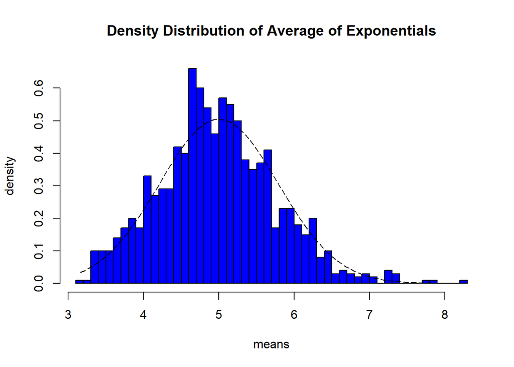

```r
data<-data.frame(rowMeans)
xfit <- seq(min(rowMeans), max(rowMeans), length=100)
yfit <- dnorm(xfit, mean=1/lambda, sd=(1/lambda/sqrt(n)))
hist(data$rowMeans,breaks=n,prob=T,col="blue",xlab = "means",main="Density Distribution of Average of Exponentials",ylab="density")
lines(xfit, yfit, pch=22, col="black", lty=5)
```